# Financial Analytics #1

Mark Preston

January 18, 2019

## Download and analyze excess returns of S&P 500

### Calculate continuous daily excess returns of SP500 (“^GSPC”) for the period from 1/1/2014 until 12/31/2014 using overnight Fed Funds rates as risk-free rates.

To begin the analysis, I’m loading the necessary data and packages. The section calls for downloading excess returns for the SP500, which can be done using `getSymbols` from the quantmod package. The function accesses and API to get the necessary data from one of several finance sites. Alongside this, I’ve uploaded overnight Fed Fund values, which will be used as the risk-free rate during the calculations.

```r
library(tidyverse)
library(quantmod)
library(kableExtra)
library(knitr)

#setting prefered ggplot theme
theme_set(
  theme_minimal()
)

#custom table function used throughout analysis
custom_kable <- function(x){
  kable(x, format = "html") %>%
    kable_styling(bootstrap_options = "striped")
}


fed_rates <- read.csv("RIFSPFF.csv", stringsAsFactors = F) %>%
  rename(date = Time.Period,
         risk_free_rate = RIFSPFF_N.D) %>%
  mutate(date = as.Date(date, format = "%m / %d / %Y"))

getSymbols(Symbols = "^GSPC", from = "2014-1-1", to = "2014-12-31")
```

```
## [1] "GSPC"
```

```r
sp_500 <- GSPC %>%
  as.data.frame() %>%
  rownames_to_column(var = "date") %>%
  mutate(SP500_return = c(0, diff(GSPC.Close) / GSPC.Close[seq(2, nrow(GSPC), 1)]),
         SP500_return = round(SP500_return, 9),
         date = as.Date(date)) %>%
  left_join(x = ., y = fed_rates, by = "date") %>%
  mutate(risk_free_rate = risk_free_rate / 360,
         excess_return = SP500_return - risk_free_rate) %>%
  slice(-1) %>%
  select(date, SP500_return, risk_free_rate, excess_return)

sp_500 %>%
  head() %>%
  custom_kable()
```

| date | SP500_return | risk_free_rate | excess_return |
| --- | --- | --- | --- |
| 2014-01-03 | -0.0003331 | 0.0002222 | -0.0005553 |
| 2014-01-06 | -0.0025181 | 0.0002222 | -0.0027403 |
| 2014-01-07 | 0.0060450 | 0.0001944 | 0.0058506 |
| 2014-01-08 | -0.0002123 | 0.0001944 | -0.0004067 |
| 2014-01-09 | 0.0003482 | 0.0001944 | 0.0001537 |
| 2014-01-10 | 0.0023014 | 0.0001944 | 0.0021069 |

With the excess returns calculated, I’ve visualized them alongside the risk free rate here. As seen, the fed risk-free rate is consistently stable while the SP 500 excess returns fluctuate across the series. I think they appear, on average, to be higher than the risk free rate.

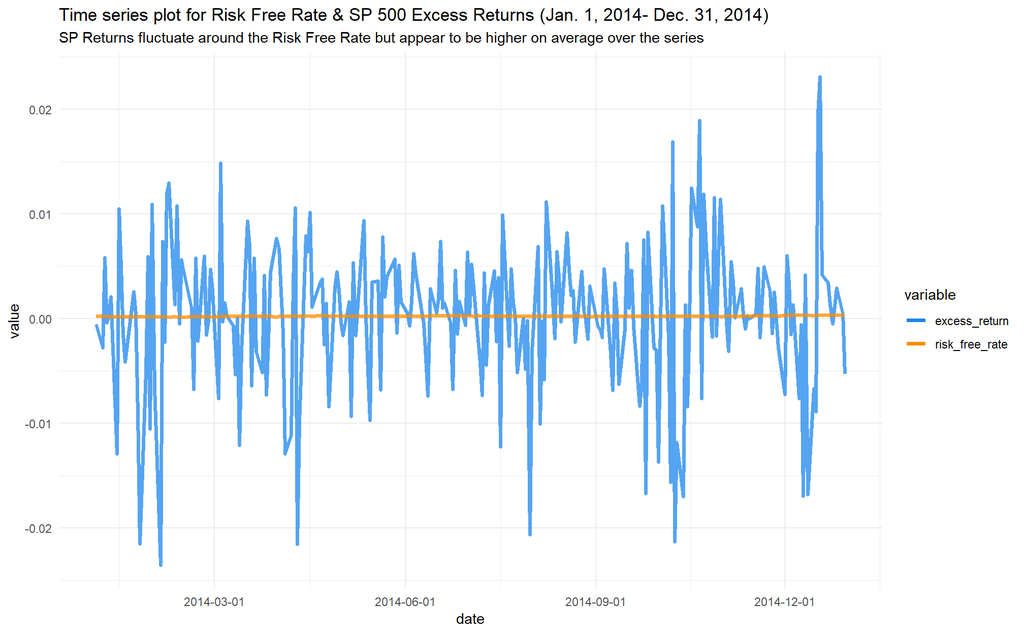

```r
sp_500 %>%
  select(date, risk_free_rate, excess_return) %>%
  gather(key = "variable", value = "value", -date) %>%
  ggplot(aes(date, value, colour = variable, group = variable)) +
  geom_line(size = 1.3, alpha = .75) +
  scale_x_date(breaks = "3 months") +
  scale_colour_manual(values = c("dodgerblue2", "darkorange")) +
  guides(colour = guide_legend(override.aes = list(alpha = 1))) +
  labs(title = "Time series plot for Risk Free Rate & SP 500 Excess Returns (Jan. 1, 2014- Dec. 31, 2014)",
       subtitle = "SP Returns fluctuate around the Risk Free Rate but appear to be higher on average over the series")
```

Some summary statistics for the the excess returns can be seen below which confirms the daily excess return is on average higher than the risk free rate here. Given the positive mean, it appears that it would have been preferable to the risk free rate. An investor holding this fund would, on average, earn returns each day over the risk free rate. Overall, this means that holding an SP 500 index during this period would be a better investing decision than having held money in the risk free rate, which is an intuitive result for this era.

```r
sp_500 %>%
  summarise(excess_return_min = min(excess_return),
            excess_return_mean = mean(excess_return),
            excess_return_median = median(excess_return),
            excess_return_max = max(excess_return)) %>%
  custom_kable()
```

| excess_return_min | excess_return_mean | excess_return_median | excess_return_max |
| --- | --- | --- | --- |
| -0.0235598 | 0.0002355 | 0.0004672 | 0.0230909 |

[figure not shown]

```r
sp_500 %>%
  ggplot(aes(excess_return)) +
  geom_density(fill = "dodgerblue2", colour = "darkgray", alpha = .5) +
  geom_vline(xintercept = mean(sp_500$excess_return), size = 1.3,
             colour = "darkorange", alpha = .5) +
  labs(title = "Density plot for SP 500 Excess Returns (Jan. 1, 2014- Dec. 31, 2014)",
       subtitle = paste0("Distribution appears to Platykurtic with kurtosis of ",
                         round(psych::kurtosi(x = sp_500$excess_return), 3),
                        "; Orange line is mean")
  )
```

## Download and analyze exchange rates for GBP/USD and USD/JPY

### Calculate daily log returns for both exchange rates

The `getSymbols` function can be used again here to extract the currency exchange rates for the Pound/USD and USD/Yen. Once the rates are downloaded, I’ve made a function that turns the values into a data frame and adds the data as a formal column. Using this, both sets can be joined for the analysis. Following this, the daily log returns are derived by differencing the log exchange rate for each column ($ln(P_t) - ln(P_t -_1)$). Having done this for both exchanges, I’ve dropped the first row given it doesn’t have a log return value.

```r
getSymbols(Symbols = "GBP/USD", src = "oanda")
```

```
## [1] "GBPUSD"
```

```r
getSymbols(Symbols = "USD/JPY", src = "oanda")
```

```
## [1] "USDJPY"
```

```r
symbol_clean <- function(data){
  set <- data %>%
    as.data.frame() %>%
    rownames_to_column(var = "date") %>%
    mutate(date = as.Date(date))

  return(set)
}

exchange_rates <- inner_join(x = symbol_clean(data = GBPUSD),
                             y = symbol_clean(data = USDJPY),
                             by = "date") %>%
  mutate(gbp_usd_lr = c(0, diff(log(GBP.USD))),
         usd_yen_lr = c(0, diff(log(USD.JPY)))) %>%
  rename_all(tolower) %>%
  slice(-1)

exchange_rates %>%
  head() %>%
  custom_kable()
```

| date | gbp.usd | usd.jpy | gbp_usd_lr | usd_yen_lr |
| --- | --- | --- | --- | --- |
| 2018-07-23 | 1.312462 | 111.1797 | -0.0007464 | -0.0022925 |
| 2018-07-24 | 1.312226 | 111.2122 | -0.0001798 | 0.0002918 |
| 2018-07-25 | 1.316201 | 111.0834 | 0.0030246 | -0.0011582 |
| 2018-07-26 | 1.316084 | 110.9556 | -0.0000889 | -0.0011518 |
| 2018-07-27 | 1.310618 | 111.0413 | -0.0041619 | 0.0007720 |
| 2018-07-28 | 1.310560 | 111.0310 | -0.0000443 | -0.0000924 |

The series includes the last 180 days of exchange rates. During this time, both exchange rates show a decline but, the USD to Yen rate has gone down by about 5 points since mid-December. This means that USD isn’t trading for as many Yen as it did in August 2018.

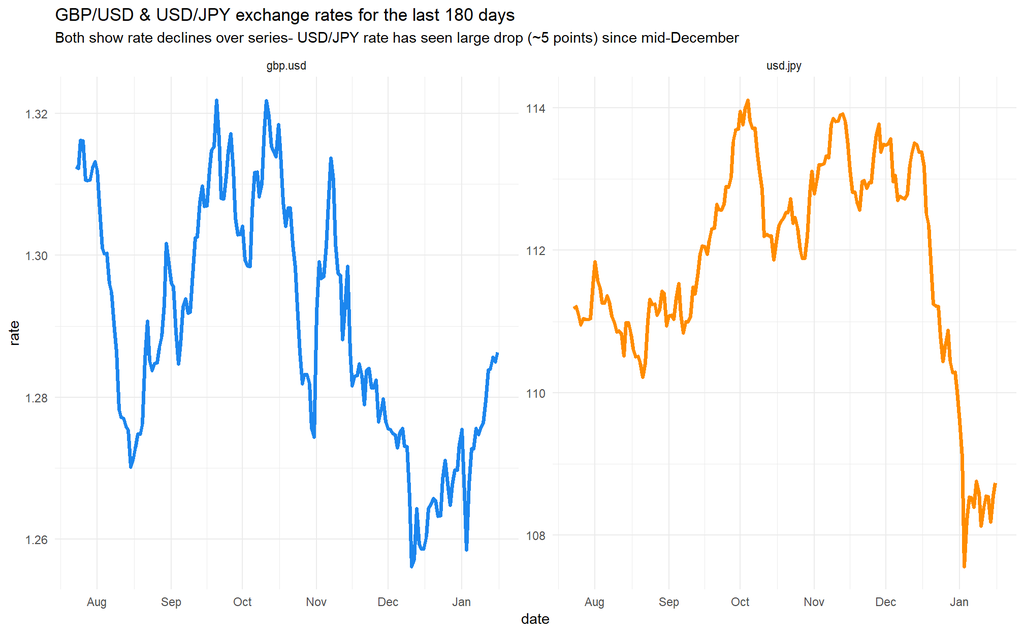

```r
exchange_rates %>%
  select(date, usd.jpy, gbp.usd) %>%
  gather(key = "currency_exchange", value = "rate", -date) %>%
  ggplot(aes(date, rate, colour = currency_exchange)) +
  geom_line(size = 1.3, show.legend = F) +
  facet_wrap(facets = "currency_exchange", scales = "free") +
  scale_colour_manual(values = c("dodgerblue2", "darkorange")) +
  labs(title = "GBP/USD & USD/JPY exchange rates for the last 180 days",
       subtitle = "Both show rate declines over series- USD/JPY rate has seen large drop (~5 points) since mid-December")
```

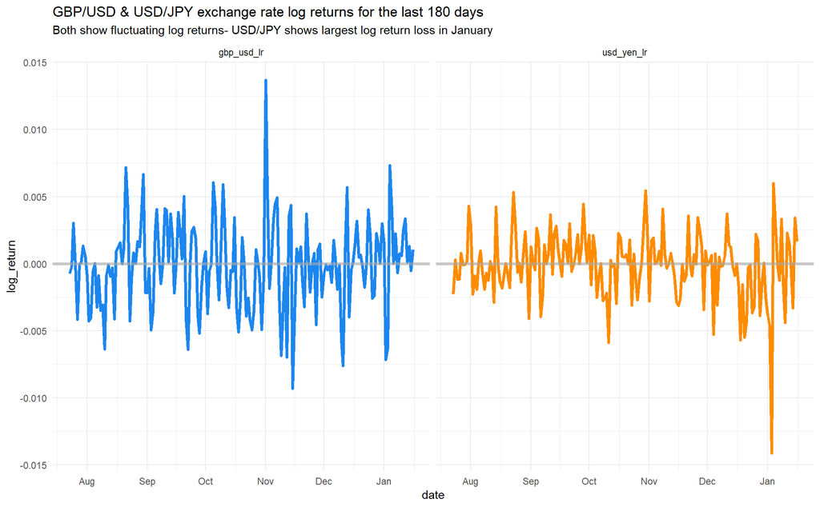

```r
exchange_rates %>%
  select(date, gbp_usd_lr, usd_yen_lr) %>%
  gather(key = "currency_exchange", value = "log_return", -date) %>%
  ggplot(aes(date, log_return, colour = currency_exchange)) +
  geom_line(size = 1.3, show.legend = F) +
  geom_hline(yintercept =  0, colour = "darkgray", size = 1.3, alpha = .6) +
  facet_wrap(facets = "currency_exchange") +
  scale_colour_manual(values = c("dodgerblue2", "darkorange")) +
  labs(title = "GBP/USD & USD/JPY exchange rate log returns for the last 180 days",
       subtitle = "Both show fluctuating log returns- USD/JPY shows largest log return loss in January")
```